# **Pemrograman Berorientasi Obyek**

Python merupakan bahasa pemrograman yang berbasis Object. Object adalah suatu variabel dengan tipe data class yang tidak hanya berisi **nilai atau state atau property**, tetapi object juga memiliki **method atau fungsi-fungsi** yang melekat pada object tersebut dan dapat juga merubah nilai object tersebut.

Berikut beberapa hal yang harus diketahui untuk Pengenalan Pemrograman Berorientasi Obyek (PBO):

1. String dan List
2. Istilah dalam PBO
3. Constructor
4. Method
5. Override Method

## **String dan List**

Contoh tipe data class yang sudah dikenal, dan digunakan sebelumnya, adalah tipe data lists ataupun string.  
Suatu variabel yang berbentuk *lists* ataupun *string*, memiliki dua buah elemen yang terkandung di dalam variabel tersebut, yaitu nilai atau yang disebut dengan *state/property*, serta *method* atau fungsi, yang dapat digunakan untuk mengolah nilai pada variabel tersebut. Method atau fungsi yang melekat pada suatu variabel dapat diakses dengan menggunakan syntax

```
namaObyek.NamaMethod()
```

### Code

Berikut adalah contoh tipe data string dan lists, yang memiliki nilai sekaligus method

```python
# String

dataStr = "Struktur Data"
print(dataStr)
dataStr = dataStr.upper()
print(dataStr)
```

```
Struktur Data
STRUKTUR DATA
```

Pada contoh code tersebut, terdapat variabel $dataStr$ yang berjenis string, dimana property dari $dataStr$adalah 'Struktur Data'. Contoh method yang digunakan adalah method $upper()$, yang berfungsi untuk merubah semua karakter pada $dataStr$ menjadi huruf kapital. Beberapa contoh method lain yang dapat digunakan adalah $capitalize()$, $lower()$, $find()$, dll.

```python
# List

dataLs = [4,10,21]
print(dataLs)
dataLs.append(45)
print(dataLs)
```

```
[4, 10, 21]
[4, 10, 21, 45]
```

Pada contoh code diatas, terdapat variabel $dataLs$ yang berbentuk lists. Variabel ini memiliki tiga buah nilai, yaitu 4, 10, dan 21. Contoh method yang digunakan adalah $append()$, yaitu menambah data pada variabel berbentuk lists. Contoh method method lain yang dimiliki tipe data lists yang bisa dimanfaatkan, misalkan $pop()$, $insert()$, $clear()$, $reverse()$, dsb.

Kembali ke Menu Awal

## **Istilah dalam Pemrograman Berorientasi Obyek**

Kelebihan dari bahasa pemrogaraman berbasis object, adalah bahasa tersebut menyediakan beberapa fitur agar *programmer* dapat membuat *class* sendiri yang sesuai dengan kebutuhan.  
Beberapa istilah dasar yang terdapat pada pemrograman berbasis object ini antara lain :

- *class*, tipe data yang tidak hanya berisi data tetapi juga method
- *object*, suatu variabel dengan tipe data *class*
- *state*, *property*, bagian data dari suatu class yang berisi nilai, dapat berupa string, integer, float
- *method*, fungsi yang melekat pada class
- *constructor*, fungsi yang dijalankan oleh python ketika pertama kali suatu objek dibuat. Method constructor ini dibuat dengan cara mendefinisikan fungsi *_ init _ (dua underscore)*
- *self*, merupakan suatu argumen atau parameter spesial agar nilai balik dari method dikembalikan ke objek itu sendiri. Argumen ini tidak perlu dipanggil (walaupun sudah didefinisikan)pada saat pemanggilan method
- *instance*, suatu objek yang telah dibuat
- *override*, mendefinisikan kembali fungsi-fungsi umum yang sudah ada, agar sesuai dengan kebutuhan programmer

Kembali ke Menu Awal

## **Constructor**

Penjelasan masing-masing fitur penting pada PBO, dilakukan langsung dengan pemberian contoh. Contoh class yang akan dibuat adalah bilangan kompleks.

Seperti yang telah diketahui, bilangan kompleks terdiri dari bilangan real dan imajiner sebagai berikut $a = x + yi$, dimana $a$ merupakan bilangan kompleks yang tersusun atas bilangan real $x$, dan bilangan imajiner $y$, dan $i = \sqrt{-1}$. Karena bilangan kompleks terdiri dari dua nilai yaitu real dan imajiner, maka bilangan kompleks ini memiliki operasi yang berbeda dibandingkan dengan bilangan lain, misalkan operasi penjumlahan, perkalian, pembagian, pengurangan, dll. Oleh karena itu, sangat tepat jika bilangan kompleks ini direpresentasikan dalam bentuk tipe data *class*.

Syntax untuk membuat suatu class, adalah sebagai berikut:

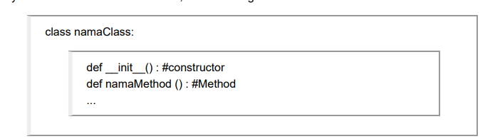

Sedangkan untuk membuat suatu obyek dengan tipe data class tertentu (proses pembuatan *instance*) adalah :

```
namaObyek = namaClass()
```

**Constructor** merupakan method yang otomatis dijalankan ketika suatu obyek dibuat. Syntax untuk pembuatan constructor ini adalah :

```
def __init__()
```

### Code

Berikut adalah contoh pembuatan tipe data ini dimulai dari mendefinisikan class dan membuat constructor dari class tersebut. Class yang akan dibuat adalah class bilangan kompleks, dimana setiap bilangan kompleks memiliki dua buah nilai, yaitu bagian real, dan bagian imajiner.

```python
class BilanganKompleks:
    def __init__(self,a,b):
        self.real = a
        self.im = b
```

```python
data = BilanganKompleks(4,6)
```

```python
# untuk mengecek tipe data dari variabel
type(data)
```

```
__main__.BilanganKompleks
```

Dari syntax-syntax tersebut, maka terdapat class dengan nama $BilanganKompleks$ sehingga terdapat tipe data baru yaitu *BilanganKompleks*.  
Ketika suatu variabel dibuat, maka variabel tersebut akan memiliki dua buah nilai yang disimpan dalam variabel didalam class yaitu *real* dan *im*, yang merupakan representasi dari bagian real dan imajiner dari suatu bilangan kompleks.

**Constructor** ini tidak perlu dipanggil secara eksplisit, akan tetapi otomatis akan dijalankan ketika *instance* (atau sebuah variabel dengan tipe data class) dibuat. Pada code diatas, perintah `text data=BilanganKompleks(4,6)` merupakan contoh instansiasi dari class bilangan kompleks, sehingga terbentuk obyek dengan nama $data$, yang memiliki nilai $real = 4$, dan nilai $im = 6$, yaitu $data = 4+6i$.

Argumen atau parameter self tidak perlu dipanggil pada saat pemanggilan method atau constructor. Ilustrasi obyek data dapat dilihat pada Gambar 1 berikut.

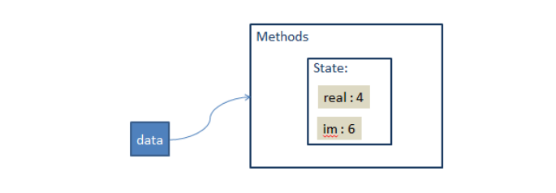

**Gambar 1. Instansiasi obyek data**

Pada contoh code sebelumnya, dilakukan syntax `type(data)` yaitu untuk mengetahui tipe data dari variabel data.

Misalkan isi dari data tersebut ingin ditampilkan, maka tidak bisa dilakukan dengan cara menulis syntax print seperti biasa, Jika tetap perintahkan print untuk menampilkan data tersebut, maka yang ditampilkan di layar hanyalah alamat tempat data tersebut disimpan, seperti contoh code berikut.

### Code

```python
class BilanganKompleks:
    def __init__(self,a,b):
        self.real = a
        self.im = b

data = BilanganKompleks(4,6)
print(data)
```

```
<__main__.BilanganKompleks object at 0x000001C7801D6A50>
```

Oleh karena itu, untuk menampilkan property atau nilai yang dimiliki oleh suatu obyek, tidak dapat dilakukan dengan syntax print() seperti biasa.

Terdapat dua cara agar objek yang sudah dibuat dapat ditampilkan di layar sesuai dengan yang diinginkan, yaitu:

- Membuat method baru untuk menampilkan data
- *override* method standar dari sebuah class

Kembali ke Menu Awal

## **Method**

Method merupakan fungsi-fungsi yang terdapat di dalam suatu class. Contoh method yang akan dibuat adalah method yang berfungsi untuk menampilkan *property* atau *state* yang terdapat di dalam suatu obyek.  
Syntax pembuatan method adalah :  
`def namamethod():`

Sedangkan untuk memanggil method suatu class adalah:  
`namaObyek.namaMethod()`

### Code

Berikut adalah contoh pembuatan method `display()` yang berfungsi untuk menampilkan *property* yang terdapat pada class Bilangan Kompleks.

```python
class BilanganKompleks:
    def __init__(self,a,b): #constructor
        self.real = a
        self.im = b
    def display(self): # method untuk menampilkan state
        print(self.real, '+',self.im,'i')
```

```python
data1=BilanganKompleks(4,6)
data1.display()
data2=BilanganKompleks(2,3)
data2.display()
```

```
4 + 6 i
2 + 3 i
```

Pada contoh code diatas, terdapat method tambahan pada class *BilanganKompleks*, yaitu method `display()`, yang berfungsi untuk menampilkan *state* atau *property* obyek dari class *BilanganKompleks*.

Di dalam method tersebut, digunakan syntax print yang berfungsi untuk menampilkan suatu data. Perintah `self.real` adalah perintah untuk mengakses *state* atau *property real*, yang dimiliki oleh class *BilanganKompleks*, begitu juga dengan perintah `self.im`, digunakan untuk mengakses *property im*. Karena *property real* dan *im* bertipe data integer, maka syntax `print()` dapat dilakukan pada dua *property* tersebut.

Kembali ke Menu Awal

## **Override Method**

**Override Method** merupakan penambahan fungsi-fungsi pada syntax-syntax yang sudah ada. Seperti yang dijelaskan sebelumnya, untuk menampilkan *property* yang terdapat pada suatu obyek, tidak dapat dilakukan dengan menggunakan perintah `print()`.

Cara pertama yang sudah dijelaskan adalah membuat method baru di dalam class, yang berfungsi untuk menampilkan *property* suatu class.

Cara kedua adalah dengan cara override method fungsi yang sudah tersedia oleh bahasa pemrograman. Syntax yang akan di*override* adalah syntax `print()`.

### Code

Berikut contoh override method `__str__` pada class BilanganKompleks

```python
class BilanganKompleks:
    def __init__(self,a,b): #constructor
        self.real = a
        self.im = b
    def display(self): # method untuk menampilkan state
        print(self.real, '+',self.im,'i')
    def __str__(self):
        return str(self.real)+" + "+str(self.im)+" i "
```

```python
data1=BilanganKompleks(4,6)
data2=BilanganKompleks(2,5)
```

```python
print('Override Method')
print(data1)
print(data2)
print('Method dalam Class')
data1.display()
data2.display()
```

```
Override Method
4 + 6 i
2 + 5 i
Method dalam Class
4 + 6 i
2 + 5 i
```

Penjumlahan dua buah bilangan kompleks berbeda dengan penjumlahan bilangan yang lain, karena bilangan kompleks ini terdiri dari dua bagian yaitu real dan imajiner. Untuk menjumlahkan bilangan kompleks, maka bagian real harus dijumlahkan pada bagian real juga dari bilangan lain, dan bagian imajiner harus ditambahkan dengan bagian imajiner, seperti persamaan berikut:

$$ \begin{align*} x1 &= x_1 + y_1i \\ x2 &= x_2 + y_2i \\ x1 + x2 &= (x_1 + y_1i) + (x_2 + y_2i) \\ &= (x_1 + x_2) + ((y_1 + y_2)i) \end{align*} $$

Seperti halnya fungsi untuk menampilkan *property* yang terdapat pada suatu class, maka untuk melakukan operasi penjumlahan ini juga dapat dilakukan dengan dua buah cara, yaitu :

- Membuat metode di dalam class untuk operasi penjumlahan
- Override method

### Code

Contoh code berikut adalah pembuatan method baru di dalam class, yang berfungsi untuk menjumlahkan dua buah bilangan kompleks.

```python
class BilanganKompleks:
    def __init__(self,a,b):
        self.real = a
        self.im = b
    def display(self):
        print(self.real, '+',self.im,'i')
    def __str__(self):
        return str(self.real)+" + "+str(self.im)+" i "
    def addKompleks(self,obj):
        a = self.real+obj.real
        b = self.im+obj.im
        return BilanganKompleks(a,b)
```

```python
data1=BilanganKompleks(4,6)
data2=BilanganKompleks(2,5)
```

```python
jumlah=data1.addKompleks(data2)
data1.display()
data2.display()
print(jumlah)
```

```
4 + 6 i
2 + 5 i
6 + 11 i
```

Jika ingin melakukan operasi penjumlahan dengan menggunakan operator'+', maka tidak dapat langsung dilakukan perintah sebagai berikut

```
data1=BilanganKompleks(4,6)
data1=BilanganKompleks(2,5)
jumlah=data1+data2
```

Operasi penjumlahan dengan oeperator '+' hanya dapat dilakukan dengan *override* fungsi `__add__` yang sudah tersedia

### Code

Berikut adalah contoh override method `__add__` , agar operasi penjumlahan dua buah bilangan kompleks dapat dilakukan dengan menggunakan operator '+'.

```python
class BilanganKompleks:
    def __init__(self,a,b):
        self.real = a
        self.im = b
    def display(self):
        print(self.real, '+',self.im,'i')
    def __str__(self):
        return str(self.real)+" + "+str(self.im)+" i "
    def addKompleks(self,obj):
        a = self.real+obj.real
        b = self.im+obj.im
        return BilanganKompleks(a,b)
    def __add__(self,obj):
        a = self.real+obj.real
        b = self.im+obj.im
        return BilanganKompleks(a,b)
```

```python
data1=BilanganKompleks(4,6)
data1=BilanganKompleks(5,10)
jumlah=data1+data2
print(data1)
print(data2)
print(jumlah)
```

```
5 + 10 i
2 + 5 i
7 + 15 i
```

Perkalian dua bilangan kompleks juga berbeda dengan perkalian bilangan biasa, karena keistimewaan bilangan kompleks ini. Perkalian dua buah bilangan kompleks dapat dilakukan sebagai berikut :

$$ \begin{align*} x1 &= x_1 + y_1i \\ x2 &= x_2 + y_2i \\ x1 \times x2 &= (x_1 + y_1i) \times (x_2 + y_2i) \\ &= (x_1 \times x_2 - y_1 \times y_2) + ((x_1 \times y_2) + (y_1 \times x_2)i) \end{align*} $$

### Code

```python
class BilanganKompleks:
    def __init__(self,a,b):
        self.real = a
        self.im = b
    def display(self):
        print(self.real, '+',self.im,'i')
    def __str__(self):
        return str(self.real)+" + "+str(self.im)+" i "
    def addKompleks(self,obj):
        a = self.real+obj.real
        b = self.im+obj.im
        return BilanganKompleks(a,b)
    def __add__(self,obj):
        a = self.real+obj.real
        b = self.im+obj.im
        return BilanganKompleks(a,b)
    def __mul__(self,data):
        temp1 = (self.real*data.real)-(self.im*data.im)
        temp2 = (self.real*data.im)+(self.real*self.im)
        return BilanganKompleks(temp1,temp2)
```

```python
a=BilanganKompleks(4,6)
b=BilanganKompleks(5,10)
c=a * b
print(a)
print(b)
print(c)
```

```
4 + 6 i
5 + 10 i
-40 + 64 i
```

### **Latihan 4**

Override method `__sub__` agar dapat dilakukan operasi pengurangan dua buah bilangan kompleks.

```python
class BilanganKompleks:
    def __init__(self, a, b):
        self.real = a
        self.im = b

    def display(self):
        print(self.real, '+', self.im, 'i')

    def __str__(self):
        return str(self.real) + " + " + str(self.im) + "i"

    # Override method pengurangan
    def __sub__(self, obj):
        # Mengurangi bagian real
        a = self.real - obj.real
        # Mengurangi bagian imajiner
        b = self.im - obj.im
        return BilanganKompleks(a, b)

# Contoh Penggunaan:
data1 = BilanganKompleks(5, 10)
data2 = BilanganKompleks(2, 5)
hasil_kurang = data1 - data2

print("Hasil Pengurangan:")
print(hasil_kurang) # Output: 3 + 5i
```

```
Hasil Pengurangan:
3 + 5i
```